# Binary Updating

Eric Novik

5/8/2018

## Beta Binomial

In general if your prior is $beta$ and your likelihood is $binomial$, your posterior is conjugate, in other words it stays in $beta$ with updated parameters. In particular if $\theta$ is the probability of success and $y$ is data (0 or 1), for a single flip, the likelihood contribution is $\theta^y * (1 - \theta)^{1-y}$. For $N$ independent trials, each data point likelihood multiplies and we get $p(y|\theta) = \prod_{n=1}^{N}\theta^y(1 - \theta)^{1-y}$. If we let the prior be $p(\theta) = \frac{1}{B(\alpha, \beta)}\theta^{\alpha-1}(1-\theta)^{\beta-1}$, where $B$ is the [$Beta$](https://en.wikipedia.org/wiki/Beta_function) function, the posterior can be worked out to be $p(\theta|y) \propto \theta^{\alpha-1+y}(1-\theta)^{\beta-1+n-y}$.

In other words, all we do is add the number of successes to one exponent and the number of failures to the other, and we have our posterior.

If we do not have any data, our posterior is our prior, namely $\beta(1, 1)$. You can see that this prior is uniform and so encodes our complete ignorance.

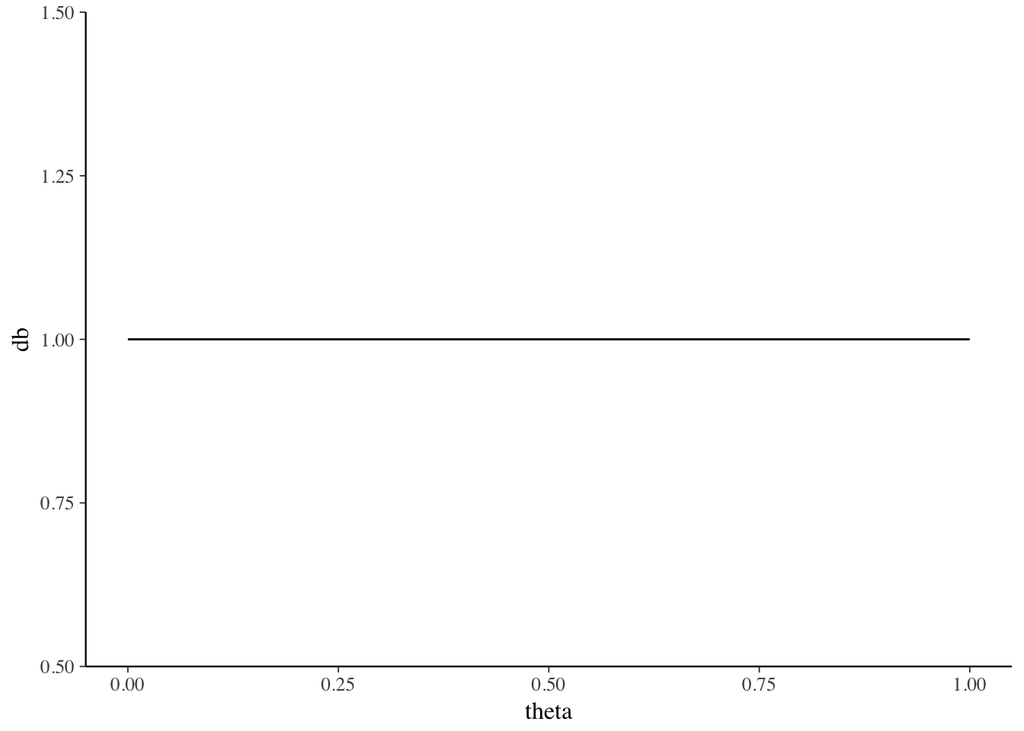

```r
theta <- seq(0, 1, length.out = 100)
db <- dbeta(theta, 1, 1)
ggplot(data.frame(theta, db), aes(theta, db)) + geom_line()
```

Now suppose we observe one success, the posterior becomes $p(\theta|y) = \theta^{\alpha-1+1}(1-\theta)^{\beta-1+1-1}$ or $beta(2, 1)$

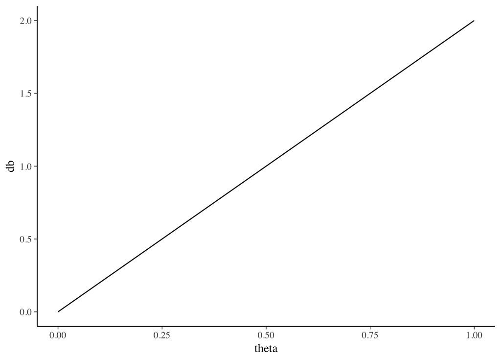

```r
db <- dbeta(theta, 2, 1)
ggplot(data.frame(theta, db), aes(theta, db)) + geom_line()
```

If we now observe a failure, the posterior becomes $\beta(2, 2)$.

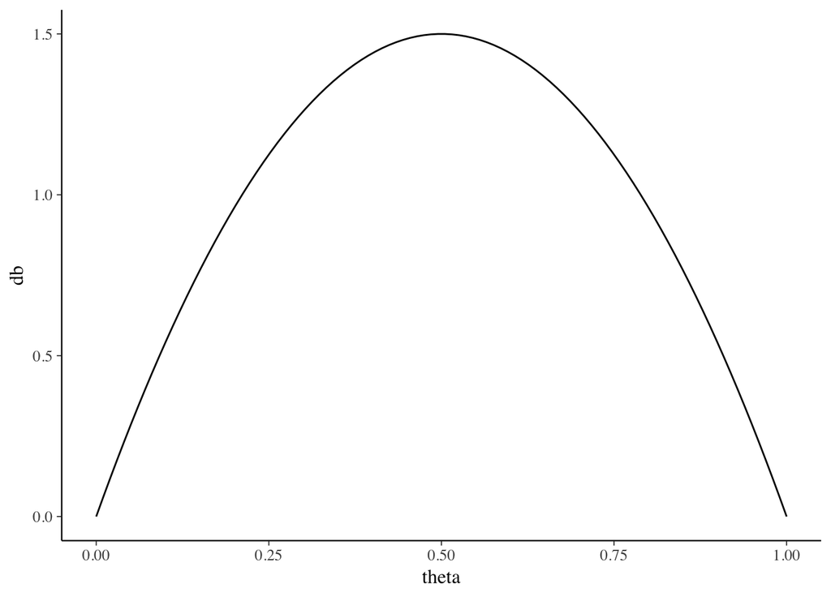

```r
db <- dbeta(theta, 2, 2)
ggplot(data.frame(theta, db), aes(theta, db)) + geom_line()
```

The nice thing is that we can update one by one (online learning) or all at once (batch). Suppose, that now we observe 5 more trials, 3 successes and 2 failures. Our new posterior is simply $\beta(5, 4)$.

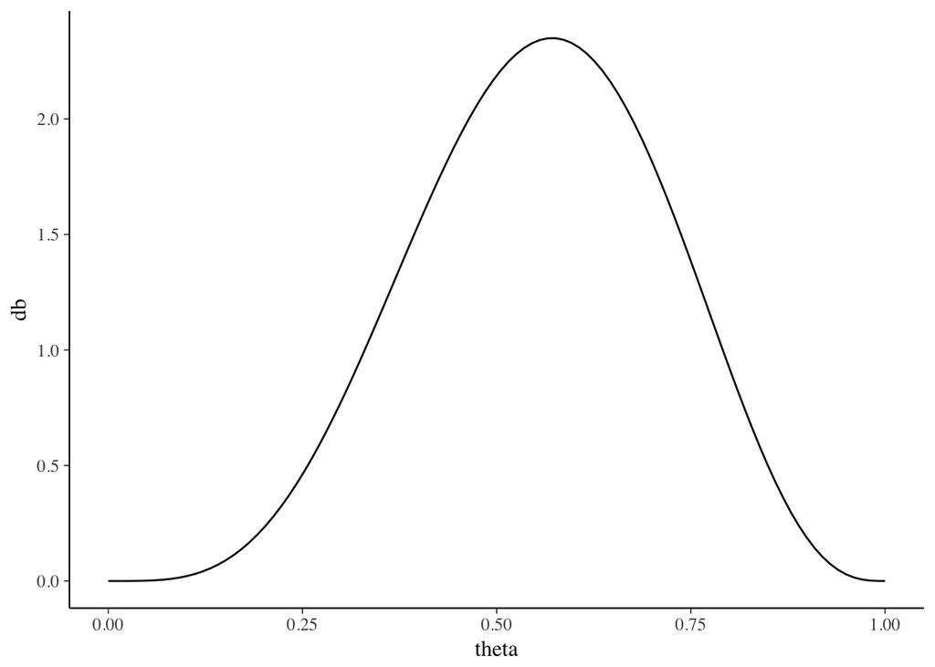

```r
db <- dbeta(theta, 5, 4)
ggplot(data.frame(theta, db), aes(theta, db)) + geom_line()
```

Now suppose we want to compute the probability of the coin bias towards heads (say 1). All we need to do is integrate this function ($\beta(5, 4)$) from $0.5$ to $1$.

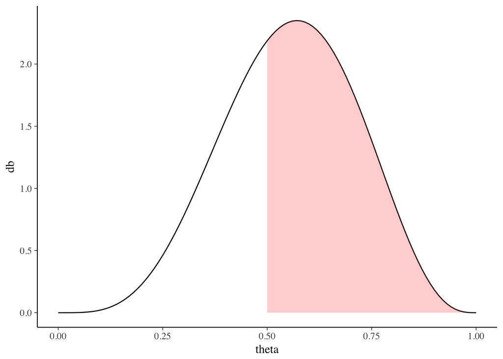

```r
ggplot(data.frame(theta = c(0, 1)), aes(theta)) +
  stat_function(fun = dbeta, args = (list(shape1 = 5, shape2 = 4))) +
  stat_function(fun = dbeta, args = (list(shape1 = 5, shape2 = 4)),
                xlim = c(0.5, 1), geom = "area", fill = "red", alpha = 1/5) +
  ylab("db")
```

```r
integrate(dbeta, lower = 0.5, upper = 1, shape1 = 5, shape2 = 4)
```

```
## 0.6367187 with absolute error < 7.1e-15
```